# Predicting Flood Damage of Northwest Florida Counties using Random Forest Regression Modeling

Author

Meagan Russell and Alexis Bjornstad (Advisor: Dr. Cohen)

Published

April 20, 2026

[Presentation Slides](https://meaganrussell.github.io/capstone4ds_MeaganAlexisCapstone/slides.html)

## Introduction

Flooding is caused by many mechanisms, including when heavy rainfall causes rivers to overflow, when impervious surfaces reduce water infiltration, and/or when soil becomes oversaturated (Javadinejad (2022); Lecce (2000)). Flash floods are considered to be one of the most severe natural disasters due to their rapid onset, unpredictability, infrastructure damage, and associated fatalities (Diakakis et al. (2020); Sadkou et al. (2024)). Infrastructure and agricultural damage costs have steadily increased in the twentieth century (Saharia et al. (2017)). According to the IPCC, the severity and frequency of flood-causing severe storms will likely increase due to climate change (Intergovernmental Panel on Climate Change (2021); Halsnæs et al. (2023)). Due to Northwest Florida’s location relative to the Gulf of Mexico and major hurricane paths, most flooding research has focused on sea-level rise and coastal flooding, leaving inland flood risk understudied (Bilskie et al. (2014); Morss et al. (2024)). Floods are extremely important to keep track of as they prove to contribute to human deaths, property damage, ecosystem changes, and social-economic losses (W. Chen et al. (2020)). Growing evidence of machine learning models’ capabilities to accurately predict storm severity and susceptibility highlights a major opportunity to apply these models to Northwest Florida (Gensini et al. (2021); Akshay et al. (2021); Z. Chen et al. (2022)).

Random Forest (RF) is a type of machine learning algorithm that predicts the dependent variable based on independent variables (Salman, Kalakech, and Steiti (2024)). RF is a smart model that uses simple models, aka decision trees (Salman, Kalakech, and Steiti (2024)). Errors produced by the random forest training can be counteracted by increasing the number of samples and trees of classification (Wang et al. (2015)). Additionally, each decision tree’s selection of data is random, which prevents the model from memorizing the data (Salman, Kalakech, and Steiti (2024)). The RF application allowed for the importance of each variable to be assessed, and each index contribution to the overall risk was calculated pertaining to the relevant study of interest in China (Wang et al. (2015)). The RF technique is optimal for performing hydrological studies due to the ability of the machine learning model to map flood risk analysis for hazard assessment with a low-cost application of the non-traditional model compared to rainfall-runoff models (Zhu and Zhang (2022)). For instance, a machine learning study in 2024 using 16 flood risk factors (FRFs), including historic flood damage locations, found that several high and very high flood risk areas closely overlapped with FEMA’s 100-year floodplain in Tampa Bay (Dey et al. (2024)). In another hydrological study, RF was able to reproduce the characteristics of the studied flood events and represented. the daily flood discharge well in comparison with the hydromad modeling (Schoppa, Disse, and Bachmair (2020)). As research progresses, it is noted that identifying key driving factors and validating them via machine learning is a key driver in precision flood prediction (Tan et al. (2024)).

## Methods

Random Forest is a supervised machine learning algorithm that introduces two sources of randomness during training. First, it uses bootstrap sampling of the training data, meaning data points are randomly selected with replacement so that the same data point may appear multiple times in a tree’s training sample, while others may not appear at all. Second, at each split within a tree, a random subset of predictor variables is considered when determining the best split. A tree continues to split until further splitting stops improving prediction or a preset depth limit is reached (Dutta, Paul, and Kumar (2023)).

In Random Forest a tree will start at a root node containing all sampled data points. Then it chooses a variable to split the data (i.e. flood versus flash flood) then splits all sampled data points by that criteria. (Rigatti (2017)) The tree creates splits on either side of the original split and then reorganizes the data points based on that criteria, as seen in Figure 1. Each decision tree corresponds to the binary split of an explanatory variable: rainfall amount, flood type, or housing unit amount. Each decision produces an outcome determined by the algorithm to create a final prediction of flood damages using random forest for the Northwest Florida counties.

Figure 1. Conceptual representation of the random forest algorithm

[figure not shown]

Random forest is a flexible, buildable, and straightforward machine learning method. Random forest produces hundreds of decision trees and binary splitting to determine the best split per possible variable. Each tree is trained with a random parameter, and the splitting function is used for the selection of the more fitting observable variable. Random forest can handle different feature types of binary, categorical, and numeric data for the use of classification, clustering, and/or regression analysis. The random forest method ensembles powerful extractions and applications of information with decision trees utilized in its model structure (Speiser et al. (2019)).

Random forest regression analysis is capable of handling large datasets and computing the variable importance of each data component. Random forest is capable of handling highly dimensional data as it produces regression trees with binary splits for outcome predictions. Random forest applies to the flood damage prediction method as it determines the model’s accuracy for optimal predictors of the dataset based on variable selection and statistical characteristics. The three datasets chosen for our prediction analysis require decision-making to develop the outcome of interest of flood damage prediction (Haddouchi and Berrado (2019)).

### Formula

Mean square error is used in random forest regression to determine the optimal splits during training and evaluate the model performance. The lower mean square error that is determined, the greater the model accuracy. The squared difference between actual and predicted values is squared (yᵢ − ŷᵢ)². 1 over the number of observations averages the total squared error. The summation symbol Σ represents the summation of the observed data points (Hodson, Over, and Foks (2021)).

$$MSE = \frac{1}{n} \sum_{i=1}^{n} (y_i - \hat{y}_i)^2$$

### Assumptions

- Each tree makes its own decisions.
- Data points are chosen randomly to reduce mistakes.
- Sufficient data ensures the trees have unique patterns and variety.
- Combining the predictions from different trees leads to a more accurate final result.

### Advantages

- Easy to identify importance of features
- Multiple decision trees tend to cause little risk of overfitting (not too close to original training data)
- Very accurate due to multiple subgroups
- Less need for data management (pre-processing to perform random forest)

### Limitations

- Slower to acquire observations for best decision making
- Bound by the lowest and highest observations (no extrapolate)
- Difficult to interpret the decisions of ‘best features’ seen with trees

## Analysis and Results

### Data Sources:

Data collected for this project utilizes the [NOAA Storm Events Database](https://www.ncdc.noaa.gov/stormevents/); daily precipitation observations from the [Global Historical Climatology Network Daily (GHCN-Daily)](https://www.ncei.noaa.gov/products/land-based-station/global-historical-climatology-network-daily); total population, total housing units, and median home value from the [American Community Survey 5-year estimates](https://data.census.gov/). Variables utilized in this study are listed in Table 1, including the source for each variable.

Table 1. Variables Used in Random Forest Model

| Variable | Description | Unit | Source |
| --- | --- | --- | --- |
| County | County where the storm event occurred | County name | NOAA Storm Events Database |
| Date | Date of the storm event | Date | NOAA Storm Events Database |
| Flood Type | Classification of event (Flood or Flash Flood) | Category | NOAA Storm Events Database |
| Property Damage | Estimated property damage caused by the storm | USD ($) | NOAA Storm Events Database |
| Rainfall (1-day) | Total precipitation during the storm day | Inches | NOAA GHCN-Daily |
| Rainfall (3-day) | Total precipitation during storm day and previous two days | Inches | NOAA GHCN-Daily |
| Rainfall (7-day) | Total precipitation during storm day and previous six days | Inches | NOAA GHCN-Daily |
| Population | Total county population | Persons | U.S. Census Bureau ACS |
| Housing Units | Total number of housing units in the county | Count | U.S. Census Bureau ACS |
| Median Home Value | Median value of owner-occupied housing units | USD ($) | U.S. Census Bureau ACS |

### Data Processing

Data from the NOAA Storm Events Database was collected for the 16 counties in Northwest Florida. Property damage and crop damage amounts were combined to create Total Damage. Flood damage amounts ranged from $0 to hundreds of millions of dollars and many of the flood events resulted in $0 damage. To account for the numerous zeros, the log of total damage was used in the random forest models.

Data from the Global Historical Climatology Network Daily was collected and precipitation days without data were given a zero for precipitation. Precipitation data was already in inches so no further calculations were required.

Wakulla County did not have any precipitation gauges in the county, so precipitation data was collected from the four surrounding counties (Jefferson, Liberty, Leon, Franklin). All days were averaged for the four counties to offer a representation of Wakulla County. In addition, new columns were created for 1-day, 3-day, and 7-day average rainfall prior to a known flood event.

Once all data sources spreadsheets were cleaned up they were merged into one spreadsheet using county name.

### Data Visualization

According to the data collected from NOAA, Northwest Florida experienced 1,203 flooding events between January 1, 2000 and December 31, 2025. Flooding event distribution is represented in Figure 2. Of the flooding events, 77.1% are categorized as flash floods and 22.9% are categorized as floods. This data indicates that Northwest Florida counties experience short-duration, high-intensity rainfall events more often then long-duration rainfall events.

Figure 2. Flash Flood vs Flood Events (2000–Present)

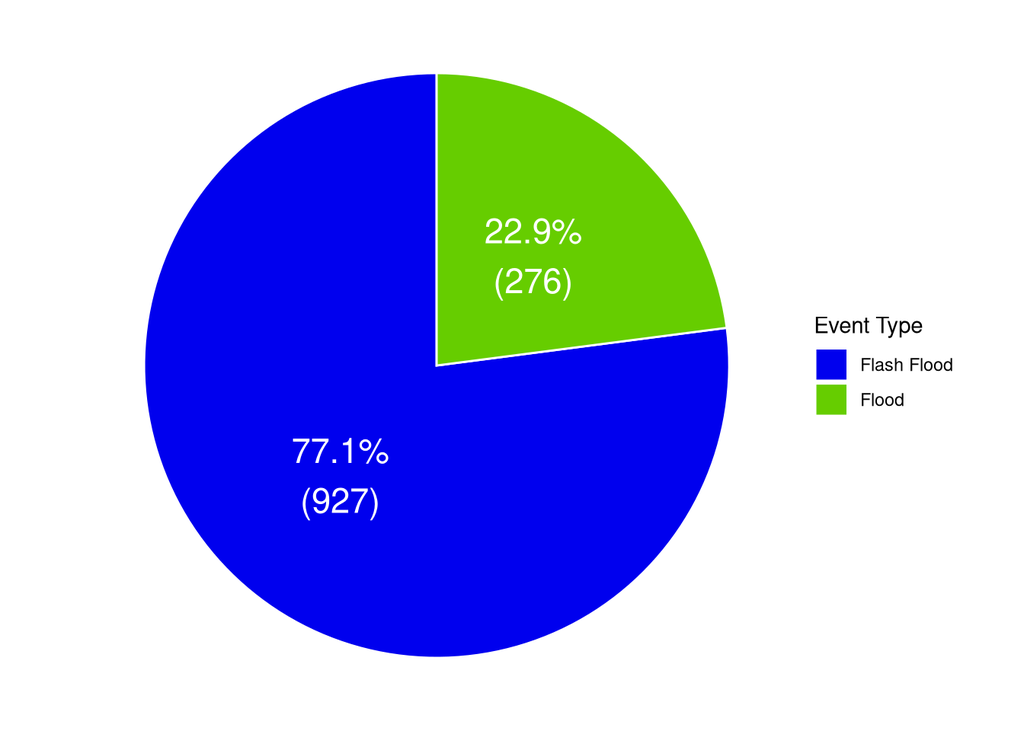

Further breaking down the dataset, Figure 3 illustrates the number of flash flood and flood events by county. Bay County experiences the highest number of flooding events, with over 150 flash floods and approximately 30 flood events recorded between January 1, 2000 and December 31, 2025. In contrast, Liberty County experienced the fewest flood events, with fewer than 25 flash floods and fewer than 10 flood events during the same time period. This pattern is likely influenced by the each county’s geographic profile. Bay County has 708 square miles of water while Liberty County has only 7.6 square miles of water (U.S. Census Bureau (2024)).

Figure 3. Flood and Flash Flood Events by County

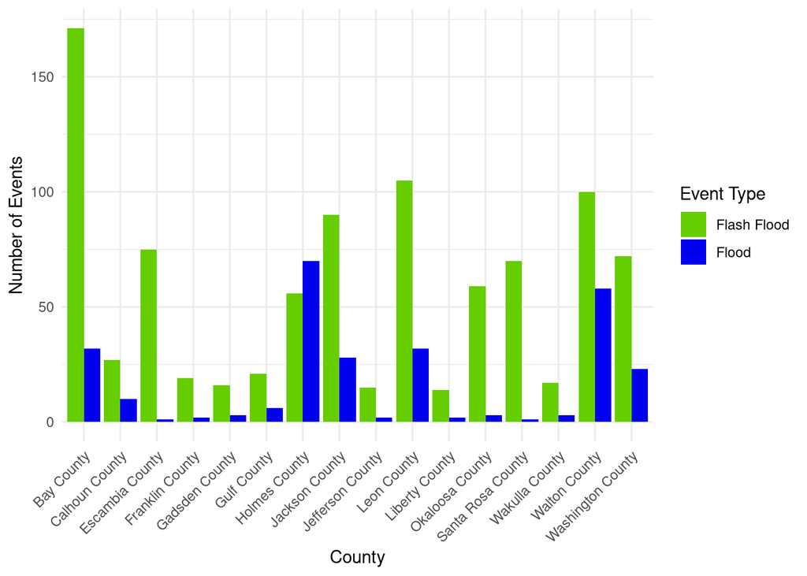

Figure 4. Flood Events and Property Damage Over Time

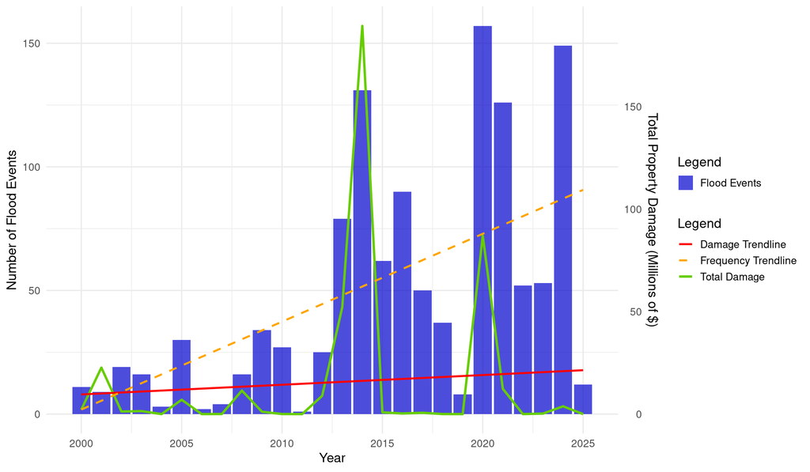

Table 2 presents the demographic variable totals obtained from the [American Community Survey 5-year estimates](https://data.census.gov/). The table includes the population size, number of housing units, and the median home values for each of the 16 Northwest Florida counties from the 2024 survey.

Table 2. Population, Housing Units, and Median Home Value by County

Population, Housing Units, and Median Home Value by County

Northwest Florida Counties (ACS 5-Year Estimates - 2024)

| County | Population | Housing Units | Median Home Value ($) |
| --- | --- | --- | --- |
| Escambia County | 325,923 | 149,217 | $257,200 |
| Leon County | 297,542 | 137,793 | $301,800 |
| Okaloosa County | 216,599 | 103,864 | $351,200 |
| Santa Rosa County | 198,472 | 80,002 | $329,800 |
| Bay County | 186,393 | 108,362 | $310,500 |
| Walton County | 82,948 | 61,272 | $425,100 |
| Jackson County | 48,250 | 20,145 | $120,800 |
| Gadsden County | 43,710 | 19,144 | $174,900 |
| Wakulla County | 35,387 | 14,599 | $258,300 |
| Washington County | 25,529 | 11,044 | $171,000 |
| Holmes County | 19,513 | 8,659 | $110,200 |
| Gulf County | 15,131 | 9,362 | $250,000 |
| Jefferson County | 15,091 | 6,886 | $232,600 |
| Calhoun County | 13,492 | 5,683 | $145,300 |
| Franklin County | 12,553 | 8,562 | $273,300 |
| Liberty County | 7,687 | 3,238 | $127,300 |

Accurate representation of property damage is essential to creating an accurate and usable model. Due to inflation, property damage values from 20 years ago is not an accurate representation of present day dollars. To improve accuracy, the NOAA data utilized for the model was reduced to the past six years, starting in January 2020. The sample size in this data range was large enough for the Random Forest Model, while portraying meaningful property damage amounts.

Figure 5. Average Monthly Rainfall by County

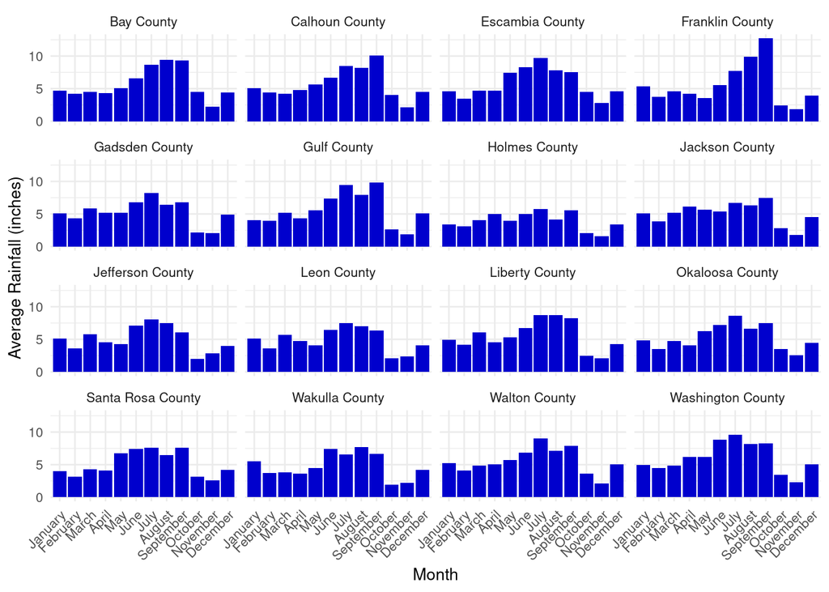

As shown in Figure 5, rainfall amounts are highest during the summer months. However, Figure 6 indicates that flood events occur more frequently in September and April.

Figure 6. Average Number of Flood Events per Month

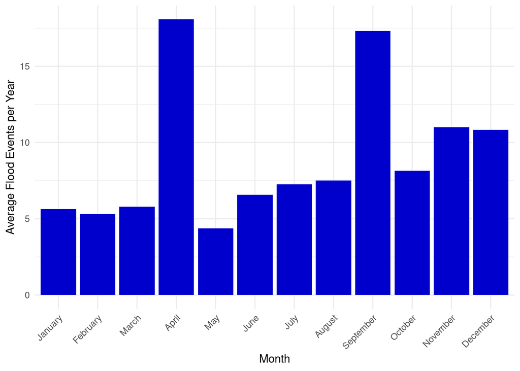

In order to verify this theory, rainfall daily maximums were calculated per month (Figure 7). This figure shows that rainfall daily maximums are highest in September, suggesting that September experiences high-intensity but less frequent rainfall events which may contribute to more frequent flooding events.

Figure 7. Maximum Daily Rainfall by Month

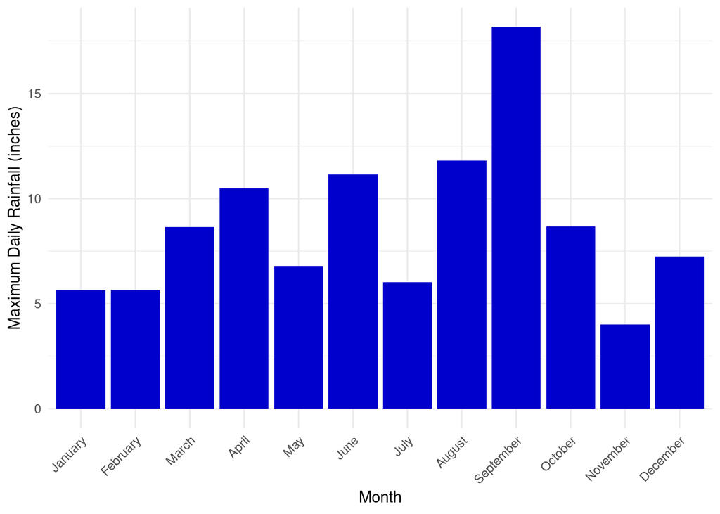

### Random Forest

To develop and evaluate the models the data was separated using a 70/30 split with 70% for training and 30% for validation.

The first model ran used multiple variables to predict total damage from a known flood event. The variables were 1-day prior rainfall, 3-day prior rainfall, 7-day prior rainfall, population, housing units, and median home value. The R² and RSME for the first model were 0.001 and 2.748, respectively. These numbers suggest that the model was unable to learn anything meaningful, possibly due to the number of flood events with zero damage.

To verify our assumption that the zeros from total damage were the issue with the first model, the second model of the dataset only kept events with property damage greater than zero. The second model used the same predictors: 1-day prior rainfall, 3-day prior rainfall, 7-day prior rainfall, population, housing units, and median home value. The second model preformed much better than the first model, resulting in a R² and RSME of 0.047 and 1.922, respectively. This suggests that removing the floods events with zero damage helped the model learn the relationship between rainfall, county characteristics, and damage more accurately. However, the model was still not predicting total damage very well.

To further improve the second model, the third model included exposure variables such as people and structures exposed to rainfall. To calculate these new variables, rainfall were multipled by population and rainfall by housing units. The third model still included 1-day prior rainfall, 3-day prior rainfall, 7-day prior rainfall, population, housing units, and median home value. The R² and RSME for model three were 0.017 and 2.059, respectively. These results suggested that the new variables did not improve total damage prediction and instead introduced noise to the model.

Overall, the most useful improvement was removing flood events with zero total damage and simplifying the predictor set. Hoever, the fourth model still restricted in its predictive power, which is understandable since flood damage can be influenced by many other factors not included in the datasets used for this study. For example, soil type and permeability plus elevation can influnce flood damage. To show the progession of our models, all R² and RSME values can be seen in Figure 8.

Figure 8. Random Forest Model Performance Comparison

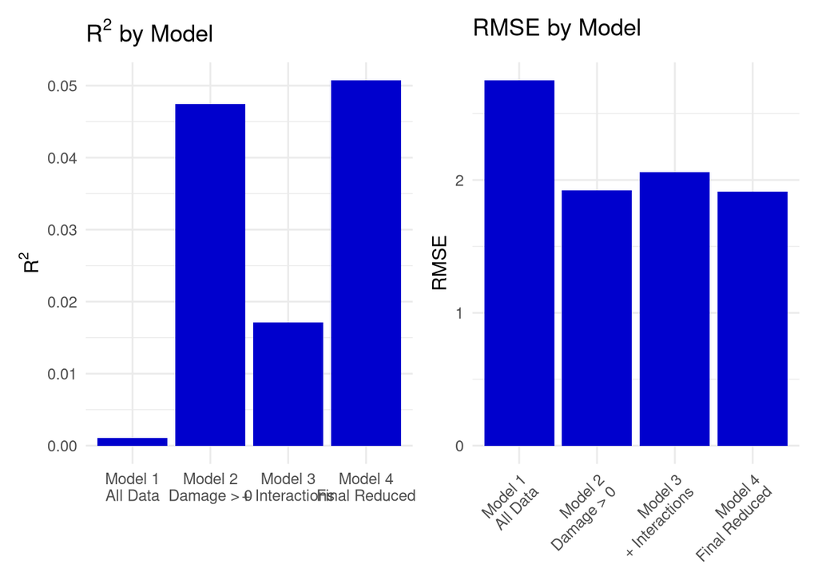

To visualize the predictive power of Model 1 and 4, a predicted vs. actual scatter plot was created (Figure 9). In Model 1 the plot shows substantial scatter, indicating the model had poor predictive capability. Model 4 provided a slight improvement, with the values falling somewhat closer to the 1:1 reference line, however, they were not tight to the line. Model 4 also had limited ability to accuractly predict the total damage from floods.

Figure 9. Predicted vs Actual Flood Damage for Model 1 and Model 4

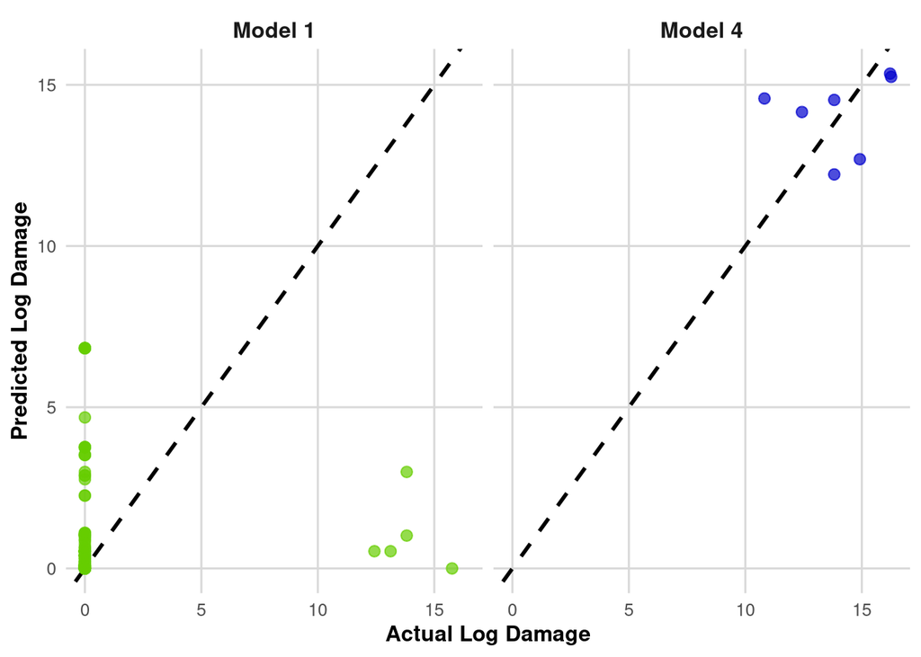

Though the models did not have strong predictive power for total damage, the predicitive damage by county could be calcualted. In Figure 10, the top counties and their predicted total damage can be seen.

Figure 10. Average Predicted Flood Damage by County

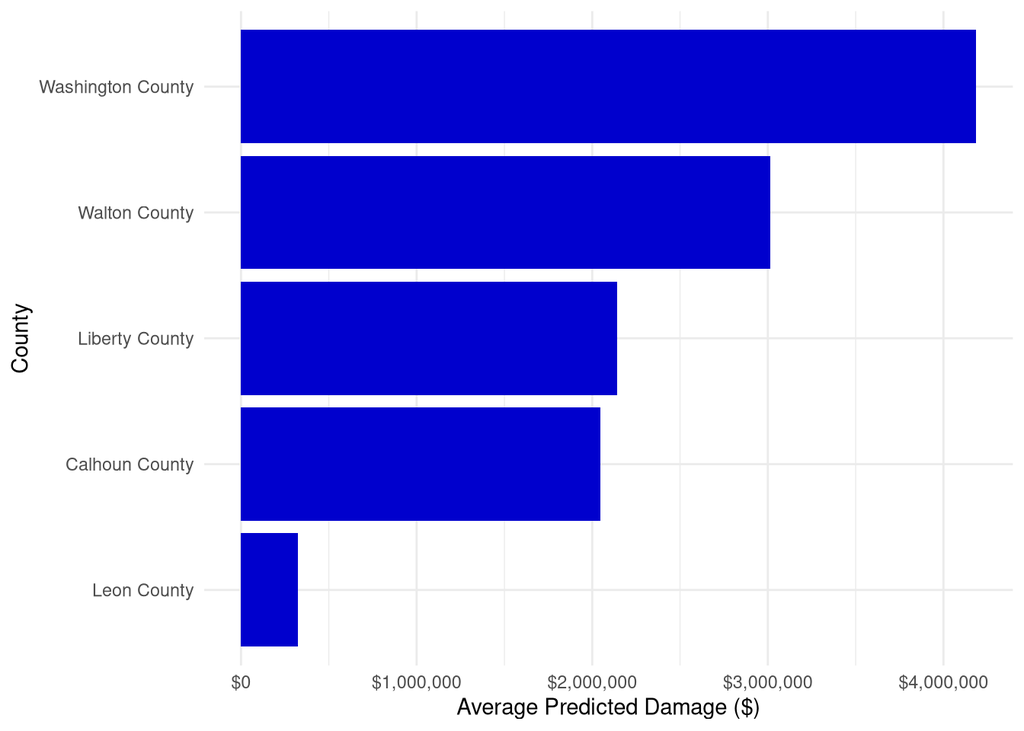

## Discusssion

The results of this study showed that the random forest model had a limited ability to predict flood damage, as demonstrated by the low R² values across each model. This suggests that flood damage is influenced by factors not included in this study. Previous research on flood susceptibility using random forest has utilized variables such as elevation, slope, aspect, distance to streams, distance to rivers, distance to roads, land cover, topographic wetness index, stream power index, and plan and profile curvature. These studies found that elevation, slope, and proximity to rivers and streams were the primary controlling factors influencing flood susceptibility (Wahba et al. (2024)).

The limitations to this study were the number and type of variables utilized, which shows the complexity of flooding. Floods don’t only occur due to heavy rainfall, but are also influenced by geophysical factors.

This study highlights the need for further research in this area and suggests that the inclusion of additional variables is critical for improving the prediction of flood damage.

## Conclusion

The random forest model is a machine learning method that is useful for classifying information and predicting outcomes. When applied to the flood damage study set, the random forest algorithm was unable to capture the total damage using multiple variables over four model types. Our best model type was transformed to include 1-day prior rainfall, population, housing units, and median home value, and continued to exclude zero-damage events. The focus on the short-term rainfall occurrences was used to inform damage predictions due to the random forest modeling type. The random forest model handles short-term predictions well due to the model handling noise and non-stationary features of datasets. In conclusion, the model improvements indicated the importance value of certain flooding variables within the model’s prediction. The factors of importance included removing zero damage flooding events to improve damage accuracy, mitigating noise factors that were introduced to the model, and simplifying predictive analysis to a short-term focus type (1 day rainfall).

The finalized model experienced limited capabilities of predicting flood damage estimations. However, a comparative analysis of our original analyzed model one versus our finalized model four revealed the improvement in actual vs. predicted values. The study revealed high damage counties in Northwest Florida, the top five in order being: Washington, Walton, Liberty, Calhoun, and Leon County. The top five counties of average predicted damage ranged in value, from the lowest prediction being <$500,000 in damage and the highest prediction totaling >$4,000,000 dollars in damages.

## References

Akshay, S. et al. 2021. “Predicting Flood Severity Using Machine Learning and Hybrid Models.” *International Journal of Disaster Risk Reduction*.

Bilskie, M. V., S. C. Hagen, S. C. Medeiros, and D. L. Passeri. 2014. “Dynamics of Sea Level Rise and Coastal Flooding on a Changing Landscape.” *Geophysical Research Letters* 41 (3): 927–34. https://doi.org/10.1002/2013GL058759.

Chen, Weixin, Yilei Li, Wei Xue, Hadi Shahabi, Shupeng Li, Hao Hong, Xue Wang, et al. 2020. “Modeling Flood Susceptibility Using Data-Driven Approaches of Naïve Bayes Tree, Alternating Decision Tree, and Random Forest Methods.” *Science of The Total Environment* 701: 134979. https://doi.org/10.1016/j.scitotenv.2019.134979.

Chen, Zhen, Qingsong Wu, Sipeng Han, Jungui Zhang, Peng Yang, and Xingwu Liu. 2022. “A Study on Geological Structure Prediction Based on Random Forest Method.” *Artificial Intelligence in Geosciences* 3: 226–36. https://doi.org/10.1016/j.aiig.2023.01.004.

Dey, Hemal, Md Munjurul Haque, Wanyun Shao, Matthew VanDyke, and Feng Hao. 2024. “Simulating Flood Risk in Tampa Bay Using a Machine Learning Driven Approach.” *Npj Natural Hazards* 1: 40. https://doi.org/10.1038/s44304-024-00045-4.

Diakakis, Michalis, Neofytos Boufidis, Jose Maria Salanova Grau, Emmanuel Andreadakis, and Iraklis Stamos. 2020. “A Systematic Assessment of the Effects of Extreme Flash Floods on Transportation Infrastructure and Circulation: The Example of the 2017 Mandra Flood.” *International Journal of Disaster Risk Reduction* 47: 101542. https://doi.org/10.1016/j.ijdrr.2020.101542.

Dutta, Pijush, Shobhandeb Paul, and Asok Kumar. 2023. “Comparative Analysis of Various Supervised Machine Learning Techniques for Diagnosis of COVID-19.” In *Machine Learning for Healthcare Applications*. Elsevier. https://doi.org/10.1016/B978-0-323-85172-5.00020-4.

Gensini, Vittorio A., Cody Converse, Walker S. Ashley, and Mateusz Taszarek. 2021. “Machine Learning Classification of Significant Tornadoes and Hail in the United States Using ERA5 Proximity Soundings.” *Weather and Forecasting* 36 (6): 2143–60.

Haddouchi, Mohammed, and Abdelaziz Berrado. 2019. “A Survey of Methods and Tools Used for Interpreting Random Forest,” 1–6. https://doi.org/10.1109/ICSSD47982.2019.9002770.

Halsnæs, Kirsten, Morten Andreas Dahl Larsen, Tanya Pheiffer Sunding, and Mads Lykke Dømgaard. 2023. “The Value of Advanced Flood Models, Damage Costs and Land Use Data in Cost-Effective Climate Change Adaptation.” *Climate Services* 32: 100424. https://doi.org/10.1016/j.cliser.2023.100424.

Hodson, Timothy O., Thomas M. Over, and Sydney S. Foks. 2021. “Mean Squared Error, Deconstructed.” *Journal of Advances in Earth Systems Modeling* 13 (12): e2021MS002681. https://doi.org/10.1029/2021MS002681.

Intergovernmental Panel on Climate Change. 2021. “Weather and Climate Extreme Events in a Changing Climate.” In *Climate Change 2021: The Physical Science Basis*, edited by V. Masson-Delmotte, P. Zhai, A. Pirani, S. L. Connors, C. Péan, S. Berger, N. Caud, et al. Cambridge University Press.

Javadinejad, Safieh. 2022. “Causes and Consequences of Floods: Flash Floods, Urban Floods, River Floods, and Coastal Floods.” *Resources, Environment and Information Engineering* 4 (1): 156–66. https://doi.org/10.25082/REIE.2022.01.002.

Lecce, S. A. 2000. “Spatial Variations in the Timing of Annual Floods in the Southeastern United States.” *Journal of Hydrology* 235 (3-4): 151–69. https://doi.org/10.1016/S0022-1694(00)00273-0.

Morss, Rebecca E., David Ahijevych, Kathryn R. Fossell, Alex M. Kowaleski, and Christopher A. Davis. 2024. “Predictability of Hurricane Storm Surge: An Ensemble Forecasting Approach Using Global Atmospheric Model Data.” *Water* 16 (11): 1523. https://doi.org/10.3390/w16111523.

National Oceanic and Atmospheric Administration. 2024. “Storm Events Database.” https://www.ncdc.noaa.gov/stormevents/.

Rigatti, Steven J. 2017. “Random Forest.” *Journal of Insurance Medicine* 47 (1): 31–39. https://doi.org/10.17849/insm-47-01-31-39.1.

Sadkou, Salma, Guillaume Artigue, Noémie Fréalle, Pierre-Alain Ayral, Séverin Pistre, Sophie Sauvagnargues, and Anne Johannet. 2024. “A Review of Flash-Floods Management: From Hydrological Modeling to Crisis Management.” *Journal of Flood Risk Management* 17 (3): e12999. https://doi.org/10.1111/jfr3.12999.

Saharia, Manabendra, Pierre-Emmanuel Kirstetter, Humberto Vergara, Jonathan J. Gourley, Yang Hong, and Marine Giroud. 2017. “Mapping Flash Flood Severity in the United States.” *Journal of Hydrometeorology* 18 (2): 397–411. https://doi.org/10.1175/JHM-D-16-0082.1.

Salman, Hasan Ahmed, Ali Kalakech, and Amani Steiti. 2024. “Random Forest Algorithm Overview.” *Babylonian Journal of Machine Learning* 2024: 69–79.

Schoppa, L., M. Disse, and S. Bachmair. 2020. “Evaluating the Performance of Random Forest for Large-Scale Flood Discharge Simulation.” *Journal of Hydrology* 590: 125531. https://doi.org/10.1016/j.jhydrol.2020.125531.

Speiser, Jaime Lynn, Michael E. Miller, Janet Tooze, and Edward Ip. 2019. “A Comparison of Random Forest Variable Selection Methods for Classification Prediction Modeling.” *Expert Systems with Applications* 134: 93–101. https://doi.org/10.1016/j.eswa.2019.05.028.

Tan, X. Z., Y. Li, X. X. Wu, C. Dai, X. L. Zhang, and Y. P. Cai. 2024. “Identification of the Key Driving Factors of Flash Flood Based on Different Feature Selection Techniques Coupled with Random Forest Method.” *Journal of Hydrology: Regional Studies* 51: 101624. https://doi.org/10.1016/j.ejrh.2023.101624.

U.S. Census Bureau. 2024. “American Community Survey 5-Year Estimates.” https://data.census.gov.

Wahba, Mohamed, Radwa Essam, Mustafa El-Rawy, Nassir Al-Arifi, Fathy Abdalla, and Wael M. Elsadek. 2024. “Forecasting of Flash Flood Susceptibility Mapping Using Random Forest Regression Model and Geographic Information Systems.” *Heliyon* 10 (13): e33982. https://doi.org/10.1016/j.heliyon.2024.e33982.

Wang, Z., C. Lai, X. Chen, B. Yang, S. Zhao, and X. Bai. 2015. “Flood Hazard Risk Assessment Model Based on Random Forest.” *Journal of Hydrology* 527: 1130–41. https://doi.org/10.1016/j.jhydrol.2015.06.008.

Zhu, Z., and Y. Zhang. 2022. “Flood Disaster Risk Assessment Based on Random Forest Algorithm.” *Neural Computing and Applications* 34: 3443–55. https://doi.org/10.1007/s00521-021-05757-6.